# Interactive effects of task repetition, task motivation and task engagement on CAL in L2 writing

Webpage created and maintained by Reza Norouzian* © 2022-present

Reza Norouzian

1/3/2023

# 1 Statitical model

The best candidate model, which was fit using the `nlme` package in `R`, used in this study included several characteristics.

First, the model assumed that CAL meaures used in our study were a random sample of a larger set of possible CAL measures available in the literature. As a result, CAL measures were considered to be random-effects for each participant across all the participants.

Second, these CAL measure random-effects were found to be non-overlapping (uncorrelated) with one another within each participant across all the participants.

Third, the CAL measure random-effects seemed to have varying amounts of variation in them (i.e., were heterogeneous) across the participants.

Fourth, although the random-effects seemed to be uncorrelated, the residuals of the model seemed to be slightly correlated symmetrically for each participant across all the participants.

Finally, in addition to their correlation, the residuals of the model seemed to change as a function of different CAL measures as well as the timing of task performance.

This level of flexibility allowed the model to accommodate the various types of CAL measures, differences in their scales of measurement, as well as violations of their underlying distributional assumptions (e.g., normality).

# 2 RQ1: To what extent does task repetition associate with measures of L2 writing syntactic complexity, accuracy, and lexical complexity?

The association between task repetition and CAL measures

| time | cal | Mean | SE | Lower | Upper | t | p-value | Sig. |
| --- | --- | --- | --- | --- | --- | --- | --- | --- |
| 1 | ac_EFC/C | 0.41 | 0.07 | 0.26 | 0.56 | 5.52 | 0.00 | *** |
| 2 | ac_EFC/C | 0.35 | 0.06 | 0.23 | 0.47 | 5.97 | 0.00 | *** |
| 3 | ac_EFC/C | 0.37 | 0.05 | 0.27 | 0.47 | 7.18 | 0.00 | *** |
| 4 | ac_EFC/C | 0.95 | 0.05 | 0.86 | 1.05 | 20.05 | 0.00 | *** |
| 1 | com_CN/C | 1.09 | 0.03 | 1.03 | 1.15 | 36.38 | 0.00 | *** |
| 2 | com_CN/C | 1.06 | 0.02 | 1.02 | 1.11 | 45.92 | 0.00 | *** |
| 3 | com_CN/C | 1.08 | 0.02 | 1.04 | 1.12 | 53.85 | 0.00 | *** |
| 4 | com_CN/C | 1.11 | 0.02 | 1.07 | 1.14 | 60.56 | 0.00 | *** |
| 1 | com_CN/T | 1.84 | 0.02 | 1.81 | 1.87 | 120.80 | 0.00 | *** |
| 2 | com_CN/T | 1.81 | 0.01 | 1.78 | 1.83 | 153.32 | 0.00 | *** |
| 3 | com_CN/T | 1.89 | 0.01 | 1.87 | 1.91 | 184.80 | 0.00 | *** |
| 4 | com_CN/T | 1.91 | 0.01 | 1.89 | 1.92 | 204.81 | 0.00 | *** |
| 1 | com_DC/T | 0.87 | 0.09 | 0.70 | 1.04 | 10.21 | 0.00 | *** |
| 2 | com_DC/T | 0.72 | 0.07 | 0.59 | 0.85 | 10.91 | 0.00 | *** |
| 3 | com_DC/T | 1.05 | 0.06 | 0.94 | 1.16 | 18.43 | 0.00 | *** |
| 4 | com_DC/T | 0.95 | 0.05 | 0.85 | 1.06 | 18.36 | 0.00 | *** |
| 1 | com_MLTU | 16.24 | 0.18 | 15.89 | 16.60 | 91.43 | 0.00 | *** |
| 2 | com_MLTU | 15.39 | 0.14 | 15.12 | 15.67 | 112.16 | 0.00 | *** |
| 3 | com_MLTU | 16.51 | 0.12 | 16.27 | 16.74 | 138.67 | 0.00 | *** |
| 4 | com_MLTU | 17.07 | 0.11 | 16.85 | 17.28 | 157.56 | 0.00 | *** |
| 1 | lex_Vocd | 68.49 | 1.02 | 66.47 | 70.51 | 67.30 | 0.00 | *** |
| 2 | lex_Vocd | 69.85 | 0.79 | 68.29 | 71.41 | 88.85 | 0.00 | *** |
| 3 | lex_Vocd | 70.82 | 0.68 | 69.46 | 72.17 | 103.85 | 0.00 | *** |
| 4 | lex_Vocd | 72.16 | 0.62 | 70.93 | 73.39 | 116.29 | 0.00 | *** |
| 1 | lex_WRDFRQmc | 1.74 | 0.01 | 1.71 | 1.76 | 122.47 | 0.00 | *** |
| 2 | lex_WRDFRQmc | 1.71 | 0.01 | 1.69 | 1.74 | 156.46 | 0.00 | *** |
| 3 | lex_WRDFRQmc | 1.74 | 0.01 | 1.72 | 1.76 | 183.59 | 0.00 | *** |
| 4 | lex_WRDFRQmc | 1.76 | 0.01 | 1.75 | 1.78 | 204.10 | 0.00 | *** |

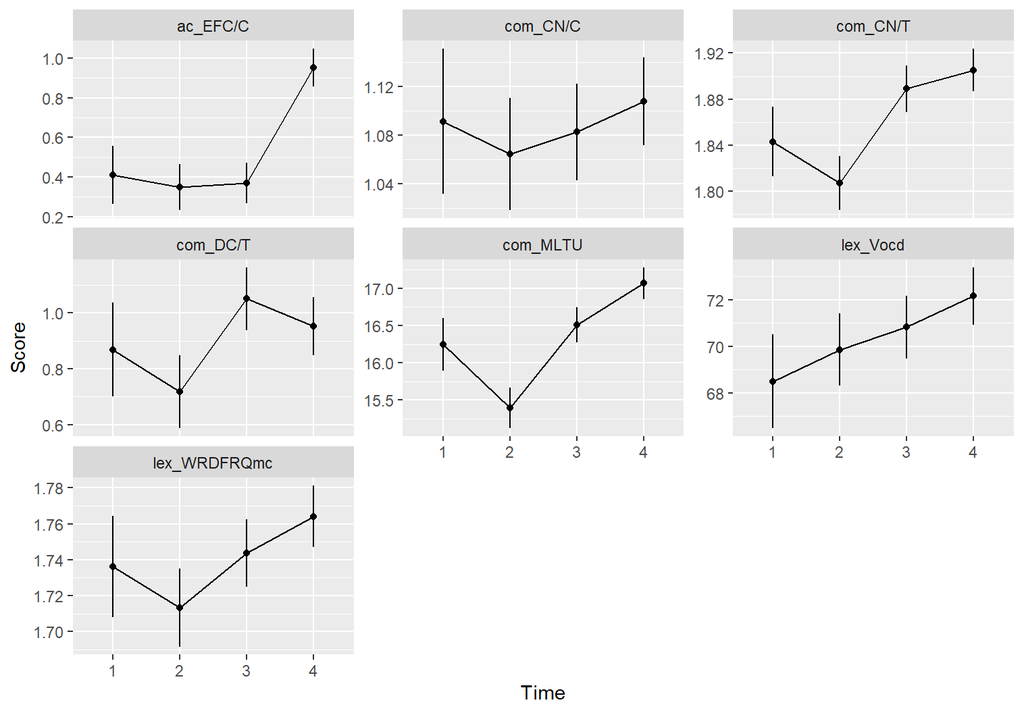

# 3 RQ2a: To what extent is that association moderated by the level of task difficulty?

The association between task repetition and CAL measures moderated by task difficulty

task_dif

time

cal

Mean

SE

Lower

Upper

t

p-value

Sig.

complex

1

ac_EFC/C

0.559

0.102

0.357

0.762

5.486

0.000

***

simple

1

ac_EFC/C

0.260

0.102

0.058

0.462

2.552

0.012

complex

2

ac_EFC/C

0.365

0.080

0.207

0.523

4.590

0.000

***

simple

2

ac_EFC/C

0.334

0.080

0.176

0.492

4.194

0.000

***

complex

3

ac_EFC/C

0.429

0.069

0.292

0.566

6.194

0.000

***

simple

3

ac_EFC/C

0.311

0.069

0.173

0.448

4.488

0.000

***

complex

4

ac_EFC/C

0.682

0.063

0.556

0.808

10.749

0.000

***

simple

4

ac_EFC/C

1.222

0.063

1.096

1.348

19.255

0.000

***

complex

1

com_CN/C

1.085

0.042

1.002

1.169

25.703

0.000

***

simple

1

com_CN/C

1.098

0.042

1.014

1.182

25.994

0.000

***

complex

2

com_CN/C

1.104

0.033

1.040

1.169

33.951

0.000

***

simple

2

com_CN/C

1.025

0.033

0.960

1.089

31.514

0.000

***

complex

3

com_CN/C

1.021

0.028

0.965

1.076

36.482

0.000

***

simple

3

com_CN/C

1.145

0.028

1.089

1.200

40.923

0.000

***

complex

4

com_CN/C

1.109

0.025

1.058

1.159

43.646

0.000

***

simple

4

com_CN/C

1.107

0.025

1.057

1.158

43.592

0.000

***

complex

1

com_CN/T

1.811

0.021

1.769

1.854

84.279

0.000

***

simple

1

com_CN/T

1.875

0.021

1.832

1.918

87.243

0.000

***

complex

2

com_CN/T

1.825

0.017

1.792

1.858

110.259

0.000

***

simple

2

com_CN/T

1.789

0.017

1.756

1.822

108.096

0.000

***

complex

3

com_CN/T

1.901

0.014

1.873

1.929

133.525

0.000

***

simple

3

com_CN/T

1.877

0.014

1.849

1.905

131.854

0.000

***

complex

4

com_CN/T

1.894

0.013

1.868

1.920

146.522

0.000

***

simple

4

com_CN/T

1.916

0.013

1.891

1.942

148.240

0.000

***

complex

1

com_DC/T

0.876

0.121

0.636

1.117

7.219

0.000

***

simple

1

com_DC/T

0.861

0.121

0.620

1.102

7.090

0.000

***

complex

2

com_DC/T

0.733

0.094

0.548

0.919

7.844

0.000

***

simple

2

com_DC/T

0.701

0.094

0.515

0.886

7.495

0.000

***

complex

3

com_DC/T

1.047

0.080

0.887

1.206

13.015

0.000

***

simple

3

com_DC/T

1.054

0.080

0.895

1.214

13.109

0.000

***

complex

4

com_DC/T

0.878

0.073

0.733

1.023

12.021

0.000

***

simple

4

com_DC/T

1.027

0.073

0.882

1.172

14.065

0.000

***

complex

1

com_MLTU

16.252

0.254

15.749

16.756

64.066

0.000

***

simple

1

com_MLTU

16.237

0.254

15.734

16.740

64.005

0.000

***

complex

2

com_MLTU

15.587

0.195

15.199

15.974

79.783

0.000

***

simple

2

com_MLTU

15.200

0.195

14.812

15.587

77.803

0.000

***

complex

3

com_MLTU

16.556

0.168

16.222

16.889

98.512

0.000

***

simple

3

com_MLTU

16.460

0.168

16.127

16.793

97.942

0.000

***

complex

4

com_MLTU

17.028

0.153

16.725

17.331

111.594

0.000

***

simple

4

com_MLTU

17.107

0.153

16.804

17.409

112.110

0.000

***

complex

1

lex_Vocd

68.860

1.443

65.998

71.723

47.731

0.000

***

simple

1

lex_Vocd

68.122

1.443

65.259

70.985

47.220

0.000

***

complex

2

lex_Vocd

69.316

1.111

67.112

71.520

62.390

0.000

***

simple

2

lex_Vocd

70.390

1.111

68.185

72.594

63.356

0.000

***

complex

3

lex_Vocd

72.334

0.956

70.438

74.231

75.685

0.000

***

simple

3

lex_Vocd

69.299

0.956

67.402

71.195

72.508

0.000

***

complex

4

lex_Vocd

71.050

0.868

69.328

72.772

81.879

0.000

***

simple

4

lex_Vocd

73.270

0.868

71.549

74.992

84.438

0.000

***

complex

1

lex_WRDFRQmc

1.740

0.020

1.700

1.780

86.124

0.000

***

simple

1

lex_WRDFRQmc

1.732

0.020

1.692

1.772

85.709

0.000

***

complex

2

lex_WRDFRQmc

1.710

0.016

1.679

1.741

109.881

0.000

***

simple

2

lex_WRDFRQmc

1.717

0.016

1.686

1.748

110.318

0.000

***

complex

3

lex_WRDFRQmc

1.759

0.013

1.732

1.785

131.378

0.000

***

simple

3

lex_WRDFRQmc

1.729

0.013

1.702

1.755

129.137

0.000

***

complex

4

lex_WRDFRQmc

1.773

0.012

1.749

1.797

145.867

0.000

***

simple

4

lex_WRDFRQmc

1.755

0.012

1.731

1.779

144.403

0.000

***

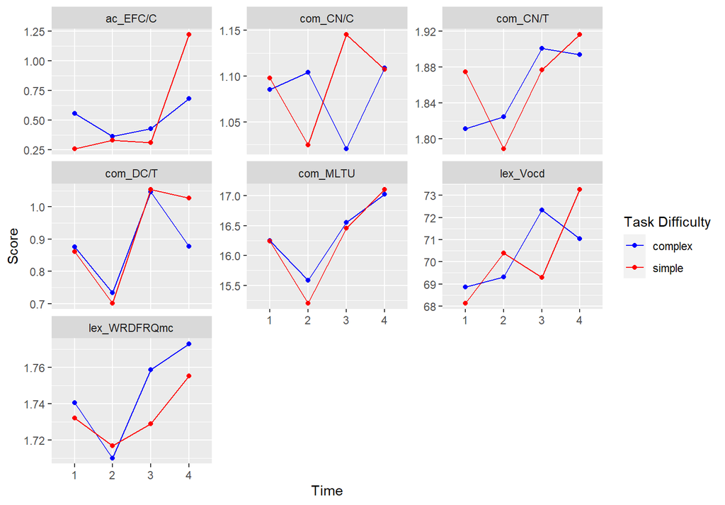

# 4 RQ2b

## 4.1 To what extent is that association moderated by the level of task external motivation?

The association between task repetition and CAL measures moderated by external motivation

| extr | time | cal | Mean | SE | Lower | Upper | t | p-value | Sig. |
| --- | --- | --- | --- | --- | --- | --- | --- | --- | --- |
| 2.100 | 1 | ac_EFC/C | 0.515 | 0.085 | 0.347 | 0.683 | 6.071 | 0.000 | *** |
| 3.200 | 1 | ac_EFC/C | 0.343 | 0.077 | 0.190 | 0.496 | 4.435 | 0.000 | *** |
| 4.300 | 1 | ac_EFC/C | 0.171 | 0.125 | -0.077 | 0.419 | 1.369 | 0.174 |  |
| 2.100 | 2 | ac_EFC/C | 0.340 | 0.071 | 0.198 | 0.482 | 4.762 | 0.000 | *** |
| 3.200 | 2 | ac_EFC/C | 0.352 | 0.058 | 0.238 | 0.466 | 6.119 | 0.000 | *** |
| 4.300 | 2 | ac_EFC/C | 0.364 | 0.089 | 0.187 | 0.541 | 4.082 | 0.000 | *** |
| 2.100 | 3 | ac_EFC/C | 0.445 | 0.081 | 0.285 | 0.605 | 5.528 | 0.000 | *** |
| 3.200 | 3 | ac_EFC/C | 0.384 | 0.051 | 0.283 | 0.484 | 7.587 | 0.000 | *** |
| 4.300 | 3 | ac_EFC/C | 0.323 | 0.063 | 0.197 | 0.448 | 5.080 | 0.000 | *** |
| 2.100 | 4 | ac_EFC/C | 0.612 | 0.073 | 0.467 | 0.756 | 8.391 | 0.000 | *** |
| 3.200 | 4 | ac_EFC/C | 0.884 | 0.046 | 0.792 | 0.976 | 19.053 | 0.000 | *** |
| 4.300 | 4 | ac_EFC/C | 1.157 | 0.057 | 1.044 | 1.269 | 20.399 | 0.000 | *** |
| 2.100 | 1 | com_CN/C | 1.080 | 0.035 | 1.010 | 1.149 | 30.829 | 0.000 | *** |
| 3.200 | 1 | com_CN/C | 1.099 | 0.032 | 1.036 | 1.162 | 34.423 | 0.000 | *** |
| 4.300 | 1 | com_CN/C | 1.118 | 0.052 | 1.016 | 1.220 | 21.660 | 0.000 | *** |
| 2.100 | 2 | com_CN/C | 1.112 | 0.029 | 1.055 | 1.170 | 38.247 | 0.000 | *** |
| 3.200 | 2 | com_CN/C | 1.051 | 0.023 | 1.005 | 1.097 | 44.925 | 0.000 | *** |
| 4.300 | 2 | com_CN/C | 0.990 | 0.036 | 0.917 | 1.062 | 27.240 | 0.000 | *** |
| 2.100 | 3 | com_CN/C | 1.002 | 0.032 | 0.938 | 1.067 | 30.931 | 0.000 | *** |
| 3.200 | 3 | com_CN/C | 1.068 | 0.020 | 1.028 | 1.108 | 52.565 | 0.000 | *** |
| 4.300 | 3 | com_CN/C | 1.133 | 0.026 | 1.083 | 1.184 | 44.391 | 0.000 | *** |
| 2.100 | 4 | com_CN/C | 1.107 | 0.029 | 1.049 | 1.164 | 38.100 | 0.000 | *** |
| 3.200 | 4 | com_CN/C | 1.108 | 0.018 | 1.071 | 1.144 | 60.049 | 0.000 | *** |
| 4.300 | 4 | com_CN/C | 1.109 | 0.023 | 1.064 | 1.154 | 49.124 | 0.000 | *** |
| 2.100 | 1 | com_CN/T | 1.823 | 0.018 | 1.787 | 1.858 | 101.484 | 0.000 | *** |
| 3.200 | 1 | com_CN/T | 1.856 | 0.016 | 1.823 | 1.888 | 113.381 | 0.000 | *** |
| 4.300 | 1 | com_CN/T | 1.889 | 0.026 | 1.837 | 1.942 | 71.382 | 0.000 | *** |
| 2.100 | 2 | com_CN/T | 1.817 | 0.015 | 1.788 | 1.847 | 121.861 | 0.000 | *** |
| 3.200 | 2 | com_CN/T | 1.804 | 0.012 | 1.780 | 1.828 | 150.401 | 0.000 | *** |
| 4.300 | 2 | com_CN/T | 1.791 | 0.019 | 1.754 | 1.828 | 96.148 | 0.000 | *** |

[output cut: 54 more lines]

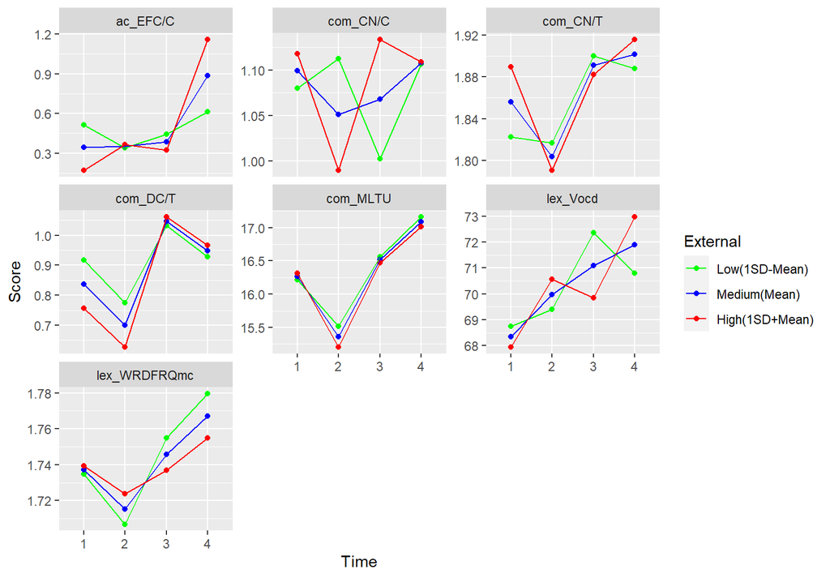

## 4.2 To what extent is that association moderated by the level of task intrinsic motivation?

The association between task repetition and CAL measures moderated by intrinsic motivation

intr

time

cal

Mean

SE

Lower

Upper

t

p-value

Sig.

1.800

1

ac_EFC/C

0.234

0.117

0.001

0.466

1.997

0.049

3.000

1

ac_EFC/C

0.379

0.074

0.232

0.525

5.135

0.000

***

4.100

1

ac_EFC/C

0.512

0.090

0.334

0.689

5.709

0.000

***

1.800

2

ac_EFC/C

0.289

0.102

0.087

0.492

2.833

0.006

3.000

2

ac_EFC/C

0.334

0.060

0.215

0.454

5.552

0.000

***

4.100

2

ac_EFC/C

0.375

0.067

0.243

0.508

5.613

0.000

***

1.800

3

ac_EFC/C

0.338

0.059

0.221

0.455

5.718

0.000

***

3.000

3

ac_EFC/C

0.390

0.053

0.284

0.495

7.326

0.000

***

4.100

3

ac_EFC/C

0.437

0.085

0.268

0.606

5.141

0.000

***

1.800

4

ac_EFC/C

1.132

0.054

1.024

1.239

20.840

0.000

***

3.000

4

ac_EFC/C

0.861

0.048

0.767

0.955

18.102

0.000

***

4.100

4

ac_EFC/C

0.613

0.073

0.468

0.757

8.406

0.000

***

1.800

1

com_CN/C

1.132

0.049

1.036

1.229

23.283

0.000

***

3.000

1

com_CN/C

1.099

0.031

1.038

1.159

35.897

0.000

***

4.100

1

com_CN/C

1.068

0.037

0.994

1.142

28.693

0.000

***

1.800

2

com_CN/C

0.996

0.042

0.913

1.079

23.768

0.000

***

3.000

2

com_CN/C

1.047

0.025

0.998

1.096

42.495

0.000

***

4.100

2

com_CN/C

1.094

0.027

1.039

1.148

39.963

0.000

***

1.800

3

com_CN/C

1.120

0.024

1.072

1.167

46.770

0.000

***

3.000

3

com_CN/C

1.060

0.022

1.017

1.103

49.222

0.000

***

4.100

3

com_CN/C

1.005

0.034

0.937

1.073

29.162

0.000

***

1.800

4

com_CN/C

1.106

0.022

1.063

1.150

50.778

0.000

***

3.000

4

com_CN/C

1.109

0.019

1.071

1.147

58.136

0.000

***

4.100

4

com_CN/C

1.111

0.029

1.053

1.169

37.945

0.000

***

1.800

1

com_CN/T

1.897

0.025

1.848

1.946

77.045

0.000

***

3.000

1

com_CN/T

1.853

0.015

1.822

1.883

119.547

0.000

***

4.100

1

com_CN/T

1.812

0.019

1.774

1.849

96.145

0.000

***

1.800

2

com_CN/T

1.770

0.021

1.728

1.812

83.425

0.000

***

3.000

2

com_CN/T

1.797

0.012

1.773

1.822

144.099

0.000

***

4.100

2

com_CN/T

1.823

0.014

1.795

1.850

131.544

0.000

***

1.800

3

com_CN/T

1.882

0.012

1.858

1.906

155.254

0.000

***

3.000

3

com_CN/T

1.894

0.011

1.872

1.915

173.715

0.000

***

4.100

3

com_CN/T

1.905

0.017

1.870

1.939

109.163

0.000

***

1.800

4

com_CN/T

1.910

0.011

1.888

1.932

173.146

0.000

***

3.000

4

com_CN/T

1.903

0.010

1.883

1.922

197.039

0.000

***

4.100

4

com_CN/T

1.896

0.015

1.866

1.925

127.891

0.000

***

1.800

1

com_DC/T

0.961

0.139

0.684

1.237

6.904

0.000

***

3.000

1

com_DC/T

0.885

0.088

0.711

1.059

10.105

0.000

***

4.100

1

com_DC/T

0.815

0.106

0.604

1.027

7.659

0.000

***

1.800

2

com_DC/T

0.558

0.120

0.320

0.796

4.655

0.000

***

3.000

2

com_DC/T

0.676

0.070

0.536

0.816

9.596

0.000

***

4.100

2

com_DC/T

0.785

0.078

0.629

0.940

10.023

0.000

***

1.800

3

com_DC/T

1.071

0.068

0.935

1.207

15.638

0.000

***

3.000

3

com_DC/T

1.038

0.062

0.916

1.160

16.851

0.000

***

4.100

3

com_DC/T

1.008

0.099

0.812

1.203

10.221

0.000

***

1.800

4

com_DC/T

0.999

0.062

0.875

1.122

16.021

0.000

***

3.000

4

com_DC/T

0.929

0.055

0.821

1.037

17.029

0.000

***

4.100

4

com_DC/T

0.865

0.084

0.699

1.032

10.332

0.000

***

1.800

1

com_MLTU

16.132

0.291

15.555

16.710

55.407

0.000

***

3.000

1

com_MLTU

16.225

0.183

15.861

16.588

88.545

0.000

***

4.100

1

com_MLTU

16.310

0.223

15.868

16.752

73.199

0.000

***

1.800

2

com_MLTU

15.019

0.251

14.521

15.516

59.872

0.000

***

3.000

2

com_MLTU

15.297

0.147

15.005

15.590

103.717

0.000

***

4.100

2

com_MLTU

15.553

0.164

15.228

15.878

94.926

0.000

***

1.800

3

com_MLTU

16.508

0.143

16.223

16.792

115.185

0.000

***

3.000

3

com_MLTU

16.508

0.129

16.252

16.764

128.070

0.000

***

4.100

3

com_MLTU

16.509

0.206

16.099

16.918

80.018

0.000

***

1.800

4

com_MLTU

17.106

0.130

16.848

17.365

131.142

0.000

***

3.000

4

com_MLTU

17.047

0.114

16.821

17.274

149.311

0.000

***

4.100

4

com_MLTU

16.993

0.175

16.645

17.341

96.955

0.000

***

1.800

1

lex_Vocd

67.642

1.658

64.352

70.932

40.798

0.000

***

3.000

1

lex_Vocd

68.342

1.043

66.271

70.412

65.497

0.000

***

4.100

1

lex_Vocd

68.983

1.269

66.465

71.500

54.369

0.000

***

1.800

2

lex_Vocd

70.893

1.428

68.058

73.727

49.630

0.000

***

3.000

2

lex_Vocd

70.119

0.840

68.453

71.786

83.488

0.000

***

4.100

2

lex_Vocd

69.410

0.933

67.559

71.261

74.397

0.000

***

1.800

3

lex_Vocd

69.663

0.816

68.044

71.283

85.362

0.000

***

3.000

3

lex_Vocd

71.533

0.734

70.077

72.990

97.457

0.000

***

4.100

3

lex_Vocd

73.248

1.175

70.917

75.579

62.348

0.000

***

1.800

4

lex_Vocd

72.605

0.743

71.132

74.079

97.747

0.000

***

3.000

4

lex_Vocd

71.935

0.650

70.645

73.225

110.643

0.000

***

4.100

4

lex_Vocd

71.320

0.998

69.340

73.301

71.460

0.000

***

1.800

1

lex_WRDFRQmc

1.731

0.023

1.685

1.777

74.409

0.000

***

3.000

1

lex_WRDFRQmc

1.735

0.015

1.706

1.764

118.511

0.000

***

4.100

1

lex_WRDFRQmc

1.739

0.018

1.704

1.774

97.671

0.000

***

1.800

2

lex_WRDFRQmc

1.720

0.020

1.681

1.760

85.822

0.000

***

3.000

2

lex_WRDFRQmc

1.715

0.012

1.692

1.739

145.527

0.000

***

4.100

2

lex_WRDFRQmc

1.710

0.013

1.684

1.736

130.643

0.000

***

1.800

3

lex_WRDFRQmc

1.738

0.011

1.715

1.760

151.736

0.000

***

3.000

3

lex_WRDFRQmc

1.748

0.010

1.727

1.768

169.661

0.000

***

4.100

3

lex_WRDFRQmc

1.757

0.016

1.724

1.789

106.549

0.000

***

1.800

4

lex_WRDFRQmc

1.757

0.010

1.737

1.778

168.576

0.000

***

3.000

4

lex_WRDFRQmc

1.768

0.009

1.749

1.786

193.737

0.000

***

4.100

4

lex_WRDFRQmc

1.777

0.014

1.749

1.805

126.886

0.000

***

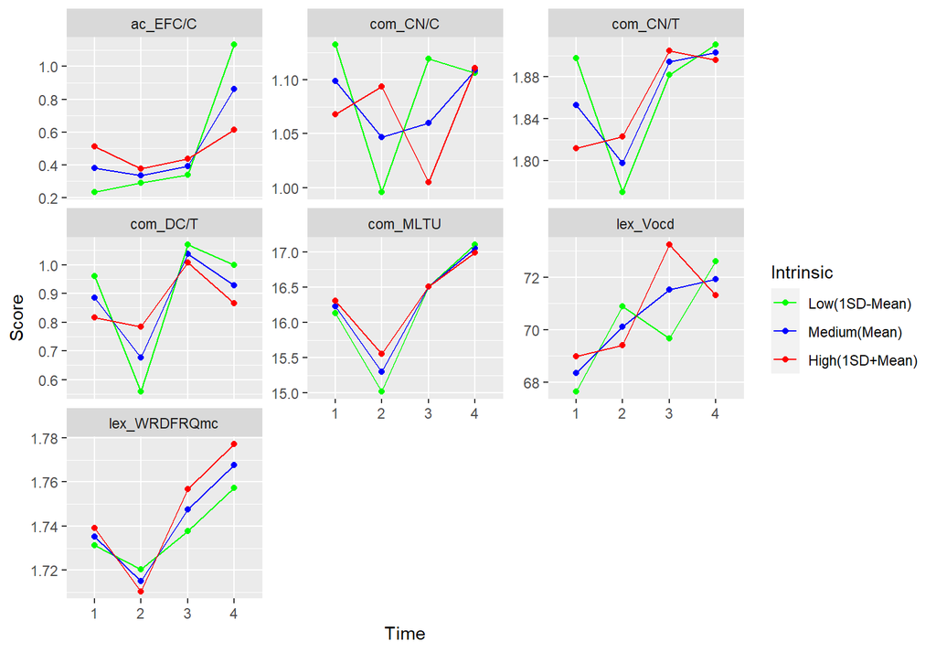

## 4.3 To what extent is that association moderated by the level of task identified motivation?

The association between task repetition and CAL measures moderated by identified motivation

iden

time

cal

Mean

SE

Lower

Upper

t

p-value

Sig.

1.700

1

ac_EFC/C

0.231

0.113

0.007

0.455

2.046

0.043

2.800

1

ac_EFC/C

0.383

0.073

0.239

0.528

5.256

0.000

***

4.000

1

ac_EFC/C

0.550

0.099

0.353

0.746

5.555

0.000

***

1.700

2

ac_EFC/C

0.263

0.097

0.070

0.455

2.708

0.008

2.800

2

ac_EFC/C

0.323

0.061

0.201

0.444

5.254

0.000

***

4.000

2

ac_EFC/C

0.388

0.066

0.257

0.520

5.852

0.000

***

1.700

3

ac_EFC/C

0.340

0.060

0.221

0.459

5.677

0.000

***

2.800

3

ac_EFC/C

0.380

0.050

0.280

0.480

7.536

0.000

***

4.000

3

ac_EFC/C

0.423

0.079

0.267

0.578

5.383

0.000

***

1.700

4

ac_EFC/C

1.134

0.055

1.024

1.243

20.516

0.000

***

2.800

4

ac_EFC/C

0.900

0.046

0.809

0.992

19.607

0.000

***

4.000

4

ac_EFC/C

0.646

0.070

0.507

0.786

9.191

0.000

***

1.700

1

com_CN/C

1.132

0.047

1.039

1.225

24.158

0.000

***

2.800

1

com_CN/C

1.097

0.030

1.037

1.158

36.258

0.000

***

4.000

1

com_CN/C

1.060

0.041

0.978

1.142

25.793

0.000

***

1.700

2

com_CN/C

1.019

0.040

0.940

1.098

25.593

0.000

***

2.800

2

com_CN/C

1.050

0.025

1.000

1.100

41.709

0.000

***

4.000

2

com_CN/C

1.085

0.027

1.031

1.139

39.870

0.000

***

1.700

3

com_CN/C

1.119

0.024

1.070

1.167

45.964

0.000

***

2.800

3

com_CN/C

1.071

0.020

1.030

1.111

52.383

0.000

***

4.000

3

com_CN/C

1.019

0.032

0.956

1.082

31.937

0.000

***

1.700

4

com_CN/C

1.108

0.022

1.064

1.152

49.781

0.000

***

2.800

4

com_CN/C

1.108

0.018

1.071

1.145

59.948

0.000

***

4.000

4

com_CN/C

1.108

0.028

1.052

1.164

39.116

0.000

***

1.700

1

com_CN/T

1.903

0.024

1.856

1.950

80.255

0.000

***

2.800

1

com_CN/T

1.852

0.015

1.822

1.882

120.872

0.000

***

4.000

1

com_CN/T

1.796

0.021

1.755

1.837

86.331

0.000

***

1.700

2

com_CN/T

1.790

0.020

1.750

1.830

88.822

0.000

***

2.800

2

com_CN/T

1.802

0.013

1.776

1.827

141.336

0.000

***

4.000

2

com_CN/T

1.814

0.014

1.787

1.842

131.756

0.000

***

1.700

3

com_CN/T

1.882

0.012

1.858

1.907

152.826

0.000

***

2.800

3

com_CN/T

1.891

0.010

1.871

1.912

182.766

0.000

***

4.000

3

com_CN/T

1.901

0.016

1.869

1.933

117.706

0.000

***

1.700

4

com_CN/T

1.909

0.011

1.887

1.932

169.493

0.000

***

2.800

4

com_CN/T

1.904

0.009

1.885

1.922

203.515

0.000

***

4.000

4

com_CN/T

1.898

0.014

1.870

1.927

132.368

0.000

***

1.700

1

com_DC/T

0.862

0.134

0.597

1.128

6.437

0.000

***

2.800

1

com_DC/T

0.868

0.087

0.696

1.040

10.025

0.000

***

4.000

1

com_DC/T

0.874

0.118

0.640

1.107

7.433

0.000

***

1.700

2

com_DC/T

0.641

0.114

0.415

0.866

5.627

0.000

***

2.800

2

com_DC/T

0.693

0.072

0.551

0.836

9.628

0.000

***

4.000

2

com_DC/T

0.751

0.078

0.597

0.905

9.653

0.000

***

1.700

3

com_DC/T

1.058

0.070

0.920

1.196

15.205

0.000

***

2.800

3

com_DC/T

1.048

0.058

0.932

1.164

17.929

0.000

***

4.000

3

com_DC/T

1.037

0.091

0.856

1.218

11.369

0.000

***

1.700

4

com_DC/T

1.008

0.064

0.882

1.134

15.837

0.000

***

2.800

4

com_DC/T

0.937

0.053

0.832

1.042

17.725

0.000

***

4.000

4

com_DC/T

0.859

0.081

0.699

1.020

10.607

0.000

***

1.700

1

com_MLTU

16.158

0.280

15.602

16.714

57.678

0.000

***

2.800

1

com_MLTU

16.232

0.181

15.873

16.591

89.685

0.000

***

4.000

1

com_MLTU

16.313

0.246

15.825

16.800

66.381

0.000

***

1.700

2

com_MLTU

15.131

0.238

14.659

15.603

63.565

0.000

***

2.800

2

com_MLTU

15.312

0.151

15.013

15.611

101.687

0.000

***

4.000

2

com_MLTU

15.510

0.163

15.187

15.832

95.337

0.000

***

1.700

3

com_MLTU

16.495

0.146

16.207

16.784

113.364

0.000

***

2.800

3

com_MLTU

16.512

0.122

16.269

16.755

135.077

0.000

***

4.000

3

com_MLTU

16.530

0.191

16.152

16.909

86.648

0.000

***

1.700

4

com_MLTU

17.087

0.133

16.823

17.351

128.411

0.000

***

2.800

4

com_MLTU

17.062

0.111

16.842

17.281

154.387

0.000

***

4.000

4

com_MLTU

17.034

0.169

16.698

17.370

100.558

0.000

***

1.700

1

lex_Vocd

67.810

1.596

64.643

70.977

42.483

0.000

***

2.800

1

lex_Vocd

68.391

1.031

66.345

70.437

66.320

0.000

***

4.000

1

lex_Vocd

69.025

1.400

66.246

71.803

49.296

0.000

***

1.700

2

lex_Vocd

70.239

1.356

67.548

72.930

51.787

0.000

***

2.800

2

lex_Vocd

69.972

0.858

68.270

71.675

81.556

0.000

***

4.000

2

lex_Vocd

69.682

0.927

67.842

71.521

75.176

0.000

***

1.700

3

lex_Vocd

69.698

0.829

68.053

71.343

84.067

0.000

***

2.800

3

lex_Vocd

71.186

0.697

69.804

72.568

102.204

0.000

***

4.000

3

lex_Vocd

72.810

1.087

70.653

74.966

66.982

0.000

***

1.700

4

lex_Vocd

72.550

0.758

71.045

74.054

95.689

0.000

***

2.800

4

lex_Vocd

72.050

0.630

70.800

73.299

114.424

0.000

***

4.000

4

lex_Vocd

71.504

0.965

69.589

73.419

74.085

0.000

***

1.700

1

lex_WRDFRQmc

1.730

0.022

1.686

1.775

77.426

0.000

***

2.800

1

lex_WRDFRQmc

1.735

0.014

1.707

1.764

120.189

0.000

***

4.000

1

lex_WRDFRQmc

1.741

0.020

1.702

1.780

88.797

0.000

***

1.700

2

lex_WRDFRQmc

1.714

0.019

1.676

1.752

90.260

0.000

***

2.800

2

lex_WRDFRQmc

1.714

0.012

1.690

1.737

142.651

0.000

***

4.000

2

lex_WRDFRQmc

1.713

0.013

1.687

1.739

132.003

0.000

***

1.700

3

lex_WRDFRQmc

1.738

0.012

1.714

1.761

149.682

0.000

***

2.800

3

lex_WRDFRQmc

1.746

0.010

1.727

1.765

179.030

0.000

***

4.000

3

lex_WRDFRQmc

1.755

0.015

1.725

1.785

115.316

0.000

***

1.700

4

lex_WRDFRQmc

1.756

0.011

1.735

1.777

165.445

0.000

***

2.800

4

lex_WRDFRQmc

1.766

0.009

1.749

1.784

200.352

0.000

***

4.000

4

lex_WRDFRQmc

1.777

0.014

1.750

1.804

131.522

0.000

***

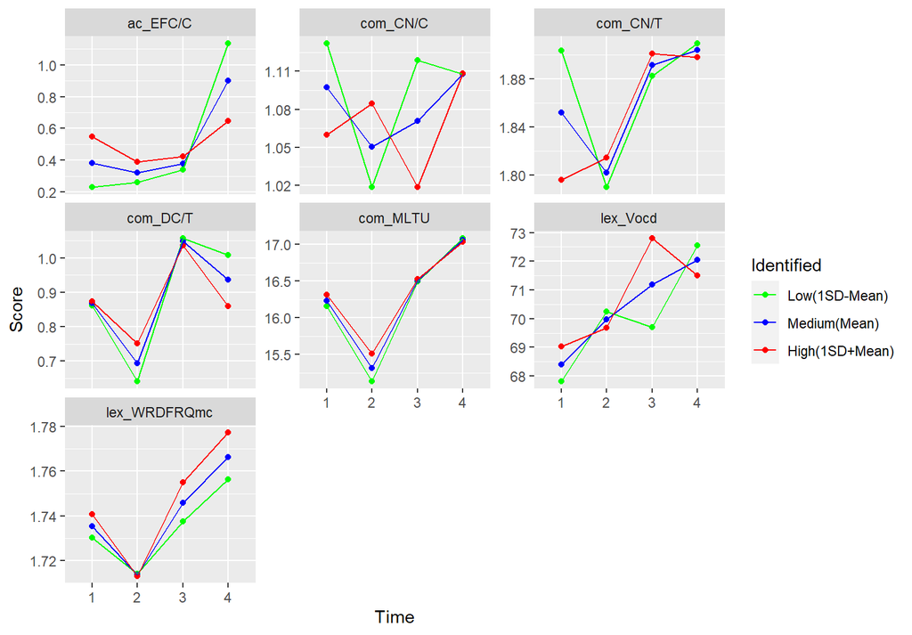

## 4.4 To what extent is that association moderated by the level of task amotivation?

The association between task repetition and CAL measures moderated by amotivation

| amot | time | cal | Mean | SE | Lower | Upper | t | p-value | Sig. |
| --- | --- | --- | --- | --- | --- | --- | --- | --- | --- |
| 2.100 | 1 | ac_EFC/C | 0.538 | 0.090 | 0.360 | 0.716 | 5.997 | 0.000 | *** |
| 3.200 | 1 | ac_EFC/C | 0.364 | 0.074 | 0.216 | 0.511 | 4.897 | 0.000 | *** |
| 4.300 | 1 | ac_EFC/C | 0.189 | 0.117 | -0.043 | 0.422 | 1.617 | 0.109 |  |
| 2.100 | 2 | ac_EFC/C | 0.339 | 0.073 | 0.193 | 0.484 | 4.607 | 0.000 | *** |
| 3.200 | 2 | ac_EFC/C | 0.351 | 0.057 | 0.239 | 0.464 | 6.211 | 0.000 | *** |
| 4.300 | 2 | ac_EFC/C | 0.364 | 0.085 | 0.196 | 0.533 | 4.291 | 0.000 | *** |
| 2.100 | 3 | ac_EFC/C | 0.448 | 0.082 | 0.284 | 0.611 | 5.431 | 0.000 | *** |
| 3.200 | 3 | ac_EFC/C | 0.385 | 0.051 | 0.285 | 0.486 | 7.605 | 0.000 | *** |
| 4.300 | 3 | ac_EFC/C | 0.323 | 0.063 | 0.198 | 0.448 | 5.118 | 0.000 | *** |
| 2.100 | 4 | ac_EFC/C | 0.591 | 0.074 | 0.445 | 0.738 | 8.022 | 0.000 | *** |
| 3.200 | 4 | ac_EFC/C | 0.879 | 0.046 | 0.787 | 0.971 | 18.962 | 0.000 | *** |
| 4.300 | 4 | ac_EFC/C | 1.166 | 0.057 | 1.054 | 1.279 | 20.558 | 0.000 | *** |
| 2.100 | 1 | com_CN/C | 1.091 | 0.037 | 1.017 | 1.165 | 29.271 | 0.000 | *** |
| 3.200 | 1 | com_CN/C | 1.092 | 0.031 | 1.030 | 1.153 | 35.390 | 0.000 | *** |
| 4.300 | 1 | com_CN/C | 1.092 | 0.049 | 0.995 | 1.188 | 22.427 | 0.000 | *** |
| 2.100 | 2 | com_CN/C | 1.108 | 0.030 | 1.048 | 1.167 | 36.768 | 0.000 | *** |
| 3.200 | 2 | com_CN/C | 1.057 | 0.023 | 1.011 | 1.103 | 45.635 | 0.000 | *** |
| 4.300 | 2 | com_CN/C | 1.007 | 0.035 | 0.938 | 1.076 | 28.926 | 0.000 | *** |
| 2.100 | 3 | com_CN/C | 1.001 | 0.033 | 0.935 | 1.068 | 29.973 | 0.000 | *** |
| 3.200 | 3 | com_CN/C | 1.067 | 0.021 | 1.026 | 1.107 | 51.998 | 0.000 | *** |
| 4.300 | 3 | com_CN/C | 1.132 | 0.026 | 1.081 | 1.182 | 44.234 | 0.000 | *** |
| 2.100 | 4 | com_CN/C | 1.115 | 0.030 | 1.056 | 1.173 | 37.632 | 0.000 | *** |
| 3.200 | 4 | com_CN/C | 1.109 | 0.019 | 1.072 | 1.146 | 59.687 | 0.000 | *** |
| 4.300 | 4 | com_CN/C | 1.104 | 0.023 | 1.059 | 1.149 | 48.490 | 0.000 | *** |
| 2.100 | 1 | com_CN/T | 1.815 | 0.019 | 1.777 | 1.853 | 95.548 | 0.000 | *** |
| 3.200 | 1 | com_CN/T | 1.853 | 0.016 | 1.822 | 1.884 | 117.944 | 0.000 | *** |
| 4.300 | 1 | com_CN/T | 1.891 | 0.025 | 1.842 | 1.941 | 76.279 | 0.000 | *** |
| 2.100 | 2 | com_CN/T | 1.821 | 0.015 | 1.791 | 1.852 | 118.689 | 0.000 | *** |
| 3.200 | 2 | com_CN/T | 1.804 | 0.012 | 1.781 | 1.828 | 152.912 | 0.000 | *** |
| 4.300 | 2 | com_CN/T | 1.788 | 0.018 | 1.753 | 1.823 | 100.830 | 0.000 | *** |

[output cut: 54 more lines]

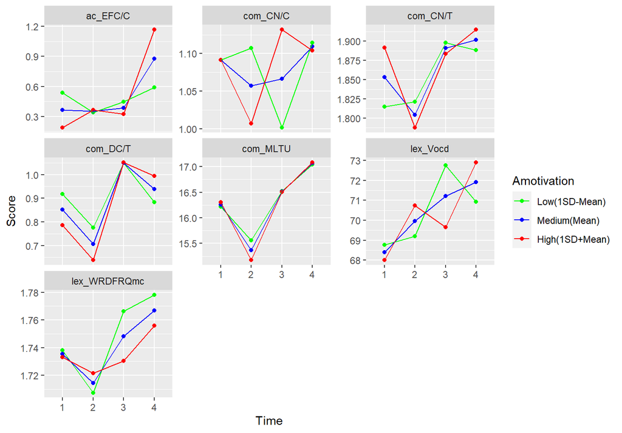

## 4.5 To what extent is that association moderated by the level of task intention?

The association between task repetition and CAL measures moderated by task intention

inten

time

cal

Mean

SE

Lower

Upper

t

p-value

Sig.

1.700

1

ac_EFC/C

0.213

0.119

-0.023

0.450

1.789

0.077

.

2.900

1

ac_EFC/C

0.368

0.075

0.219

0.518

4.898

0.000

***

4.100

1

ac_EFC/C

0.524

0.091

0.343

0.704

5.763

0.000

***

1.700

2

ac_EFC/C

0.253

0.103

0.048

0.457

2.445

0.016

2.900

2

ac_EFC/C

0.322

0.062

0.200

0.444

5.219

0.000

***

4.100

2

ac_EFC/C

0.391

0.068

0.257

0.526

5.776

0.000

***

1.700

3

ac_EFC/C

0.333

0.062

0.210

0.456

5.367

0.000

***

2.900

3

ac_EFC/C

0.386

0.052

0.282

0.489

7.386

0.000

***

4.100

3

ac_EFC/C

0.439

0.085

0.269

0.608

5.132

0.000

***

1.700

4

ac_EFC/C

1.108

0.057

0.996

1.221

19.516

0.000

***

2.900

4

ac_EFC/C

0.881

0.048

0.786

0.977

18.285

0.000

***

4.100

4

ac_EFC/C

0.654

0.079

0.498

0.811

8.315

0.000

***

1.700

1

com_CN/C

1.148

0.049

1.051

1.245

23.465

0.000

***

2.900

1

com_CN/C

1.104

0.031

1.042

1.165

35.767

0.000

***

4.100

1

com_CN/C

1.059

0.037

0.985

1.133

28.387

0.000

***

1.700

2

com_CN/C

0.987

0.042

0.904

1.070

23.580

0.000

***

2.900

2

com_CN/C

1.043

0.025

0.993

1.092

41.770

0.000

***

4.100

2

com_CN/C

1.098

0.027

1.043

1.152

40.024

0.000

***

1.700

3

com_CN/C

1.120

0.025

1.071

1.170

45.083

0.000

***

2.900

3

com_CN/C

1.066

0.021

1.025

1.108

51.036

0.000

***

4.100

3

com_CN/C

1.013

0.034

0.945

1.081

29.577

0.000

***

1.700

4

com_CN/C

1.105

0.023

1.061

1.150

49.051

0.000

***

2.900

4

com_CN/C

1.109

0.019

1.071

1.147

58.037

0.000

***

4.100

4

com_CN/C

1.113

0.031

1.051

1.175

35.597

0.000

***

1.700

1

com_CN/T

1.896

0.025

1.846

1.945

76.159

0.000

***

2.900

1

com_CN/T

1.854

0.016

1.823

1.885

118.147

0.000

***

4.100

1

com_CN/T

1.813

0.019

1.775

1.850

95.543

0.000

***

1.700

2

com_CN/T

1.776

0.021

1.734

1.818

83.402

0.000

***

2.900

2

com_CN/T

1.798

0.013

1.773

1.823

141.636

0.000

***

4.100

2

com_CN/T

1.820

0.014

1.792

1.848

130.458

0.000

***

1.700

3

com_CN/T

1.882

0.013

1.856

1.907

148.870

0.000

***

2.900

3

com_CN/T

1.892

0.011

1.871

1.913

178.035

0.000

***

4.100

3

com_CN/T

1.903

0.017

1.869

1.938

109.271

0.000

***

1.700

4

com_CN/T

1.910

0.011

1.888

1.933

166.668

0.000

***

2.900

4

com_CN/T

1.903

0.010

1.883

1.922

195.734

0.000

***

4.100

4

com_CN/T

1.895

0.016

1.863

1.927

119.160

0.000

***

1.700

1

com_DC/T

0.921

0.140

0.643

1.199

6.573

0.000

***

2.900

1

com_DC/T

0.880

0.088

0.704

1.055

9.960

0.000

***

4.100

1

com_DC/T

0.839

0.107

0.627

1.050

7.854

0.000

***

1.700

2

com_DC/T

0.550

0.120

0.312

0.788

4.588

0.000

***

2.900

2

com_DC/T

0.670

0.071

0.528

0.811

9.371

0.000

***

4.100

2

com_DC/T

0.789

0.079

0.633

0.945

10.051

0.000

***

1.700

3

com_DC/T

1.055

0.071

0.914

1.196

14.829

0.000

***

2.900

3

com_DC/T

1.049

0.060

0.930

1.168

17.533

0.000

***

4.100

3

com_DC/T

1.043

0.098

0.848

1.237

10.639

0.000

***

1.700

4

com_DC/T

1.006

0.065

0.878

1.134

15.601

0.000

***

2.900

4

com_DC/T

0.928

0.055

0.820

1.037

16.967

0.000

***

4.100

4

com_DC/T

0.850

0.090

0.672

1.028

9.498

0.000

***

1.700

1

com_MLTU

16.166

0.293

15.586

16.747

55.251

0.000

***

2.900

1

com_MLTU

16.228

0.184

15.862

16.594

87.969

0.000

***

4.100

1

com_MLTU

16.290

0.223

15.847

16.732

73.048

0.000

***

1.700

2

com_MLTU

14.942

0.250

14.446

15.439

59.690

0.000

***

2.900

2

com_MLTU

15.265

0.149

14.969

15.561

102.288

0.000

***

4.100

2

com_MLTU

15.588

0.164

15.262

15.913

95.042

0.000

***

1.700

3

com_MLTU

16.486

0.149

16.192

16.781

110.966

0.000

***

2.900

3

com_MLTU

16.517

0.125

16.269

16.765

132.195

0.000

***

4.100

3

com_MLTU

16.548

0.205

16.142

16.954

80.826

0.000

***

1.700

4

com_MLTU

17.083

0.135

16.815

17.350

126.784

0.000

***

2.900

4

com_MLTU

17.060

0.114

16.833

17.287

149.298

0.000

***

4.100

4

com_MLTU

17.037

0.187

16.667

17.408

91.139

0.000

***

1.700

1

lex_Vocd

67.379

1.668

64.069

70.689

40.393

0.000

***

2.900

1

lex_Vocd

68.257

1.052

66.170

70.344

64.903

0.000

***

4.100

1

lex_Vocd

69.135

1.271

66.612

71.658

54.380

0.000

***

1.700

2

lex_Vocd

70.524

1.427

67.692

73.356

49.417

0.000

***

2.900

2

lex_Vocd

70.044

0.851

68.355

71.732

82.328

0.000

***

4.100

2

lex_Vocd

69.563

0.935

67.708

71.418

74.399

0.000

***

1.700

3

lex_Vocd

69.508

0.847

67.827

71.188

82.063

0.000

***

2.900

3

lex_Vocd

71.385

0.712

69.972

72.798

100.217

0.000

***

4.100

3

lex_Vocd

73.262

1.167

70.946

75.578

62.769

0.000

***

1.700

4

lex_Vocd

72.569

0.768

71.045

74.093

94.474

0.000

***

2.900

4

lex_Vocd

71.976

0.651

70.683

73.268

110.487

0.000

***

4.100

4

lex_Vocd

71.382

1.066

69.268

73.497

66.980

0.000

***

1.700

1

lex_WRDFRQmc

1.734

0.023

1.688

1.781

73.980

0.000

***

2.900

1

lex_WRDFRQmc

1.736

0.015

1.706

1.765

117.446

0.000

***

4.100

1

lex_WRDFRQmc

1.737

0.018

1.702

1.773

97.241

0.000

***

1.700

2

lex_WRDFRQmc

1.716

0.020

1.676

1.756

85.550

0.000

***

2.900

2

lex_WRDFRQmc

1.714

0.012

1.690

1.738

143.363

0.000

***

4.100

2

lex_WRDFRQmc

1.712

0.013

1.686

1.738

130.321

0.000

***

1.700

3

lex_WRDFRQmc

1.738

0.012

1.715

1.762

146.036

0.000

***

2.900

3

lex_WRDFRQmc

1.746

0.010

1.726

1.766

174.443

0.000

***

4.100

3

lex_WRDFRQmc

1.754

0.016

1.722

1.787

106.943

0.000

***

1.700

4

lex_WRDFRQmc

1.758

0.011

1.736

1.779

162.838

0.000

***

2.900

4

lex_WRDFRQmc

1.767

0.009

1.749

1.785

193.009

0.000

***

4.100

4

lex_WRDFRQmc

1.776

0.015

1.746

1.806

118.590

0.000

***

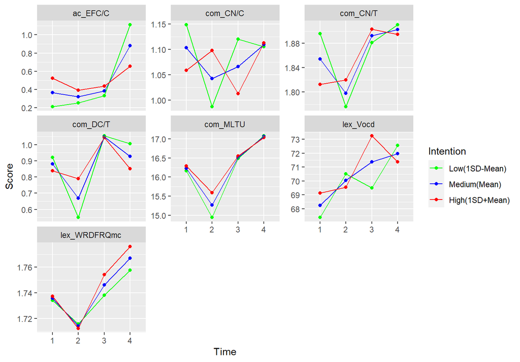

# 5 RQ2c

## 5.1 To what extent is that association moderated by the degree of time on task?

The association between task repetition and CAL measures moderated by time on task

| time_on_task | time | cal | Mean | SE | Lower | Upper | t | p-value | Sig. |
| --- | --- | --- | --- | --- | --- | --- | --- | --- | --- |
| 28.000 | 1 | ac_EFC/C | 0.208 | 0.111 | -0.013 | 0.430 | 1.871 | 0.064 | . |
| 32.600 | 1 | ac_EFC/C | 0.391 | 0.075 | 0.243 | 0.540 | 5.242 | 0.000 | *** |
| 37.200 | 1 | ac_EFC/C | 0.574 | 0.101 | 0.375 | 0.774 | 5.704 | 0.000 | *** |
| 28.000 | 2 | ac_EFC/C | 0.341 | 0.105 | 0.133 | 0.548 | 3.258 | 0.002 | ** |
| 32.600 | 2 | ac_EFC/C | 0.348 | 0.062 | 0.225 | 0.470 | 5.639 | 0.000 | *** |
| 37.200 | 2 | ac_EFC/C | 0.354 | 0.076 | 0.203 | 0.506 | 4.651 | 0.000 | *** |
| 28.000 | 3 | ac_EFC/C | 0.361 | 0.060 | 0.242 | 0.480 | 6.010 | 0.000 | *** |
| 32.600 | 3 | ac_EFC/C | 0.374 | 0.053 | 0.269 | 0.478 | 7.072 | 0.000 | *** |
| 37.200 | 3 | ac_EFC/C | 0.386 | 0.077 | 0.234 | 0.539 | 5.022 | 0.000 | *** |
| 28.000 | 4 | ac_EFC/C | 0.953 | 0.065 | 0.824 | 1.083 | 14.623 | 0.000 | *** |
| 32.600 | 4 | ac_EFC/C | 0.952 | 0.048 | 0.857 | 1.046 | 19.973 | 0.000 | *** |
| 37.200 | 4 | ac_EFC/C | 0.950 | 0.074 | 0.803 | 1.097 | 12.814 | 0.000 | *** |
| 28.000 | 1 | com_CN/C | 1.107 | 0.045 | 1.017 | 1.196 | 24.578 | 0.000 | *** |
| 32.600 | 1 | com_CN/C | 1.093 | 0.030 | 1.033 | 1.153 | 36.384 | 0.000 | *** |
| 37.200 | 1 | com_CN/C | 1.079 | 0.041 | 0.999 | 1.160 | 26.549 | 0.000 | *** |
| 28.000 | 2 | com_CN/C | 1.099 | 0.042 | 1.016 | 1.181 | 26.380 | 0.000 | *** |
| 32.600 | 2 | com_CN/C | 1.072 | 0.024 | 1.024 | 1.120 | 43.969 | 0.000 | *** |
| 37.200 | 2 | com_CN/C | 1.045 | 0.030 | 0.985 | 1.105 | 34.551 | 0.000 | *** |
| 28.000 | 3 | com_CN/C | 1.112 | 0.023 | 1.066 | 1.159 | 47.448 | 0.000 | *** |
| 32.600 | 3 | com_CN/C | 1.070 | 0.021 | 1.030 | 1.111 | 52.042 | 0.000 | *** |
| 37.200 | 3 | com_CN/C | 1.028 | 0.030 | 0.968 | 1.088 | 34.096 | 0.000 | *** |
| 28.000 | 4 | com_CN/C | 1.092 | 0.025 | 1.042 | 1.142 | 43.236 | 0.000 | *** |
| 32.600 | 4 | com_CN/C | 1.110 | 0.018 | 1.074 | 1.146 | 60.571 | 0.000 | *** |
| 37.200 | 4 | com_CN/C | 1.128 | 0.029 | 1.071 | 1.185 | 39.216 | 0.000 | *** |
| 28.000 | 1 | com_CN/T | 1.879 | 0.023 | 1.833 | 1.924 | 82.399 | 0.000 | *** |
| 32.600 | 1 | com_CN/T | 1.846 | 0.015 | 1.816 | 1.876 | 121.388 | 0.000 | *** |
| 37.200 | 1 | com_CN/T | 1.814 | 0.021 | 1.773 | 1.855 | 88.136 | 0.000 | *** |
| 28.000 | 2 | com_CN/T | 1.783 | 0.021 | 1.741 | 1.825 | 84.561 | 0.000 | *** |
| 32.600 | 2 | com_CN/T | 1.802 | 0.012 | 1.777 | 1.826 | 145.950 | 0.000 | *** |
| 37.200 | 2 | com_CN/T | 1.820 | 0.015 | 1.790 | 1.851 | 118.826 | 0.000 | *** |

[output cut: 54 more lines]

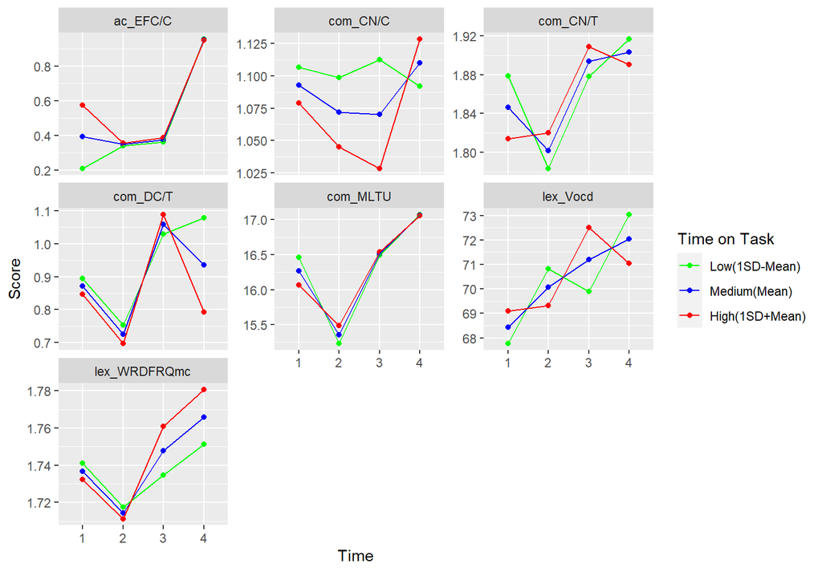

## 5.2 To what extent is that association moderated by the length of writing?

The association between task repetition and CAL measures moderated by writing length

| length_writing | time | cal | Mean | SE | Lower | Upper | t | p-value | Sig. |
| --- | --- | --- | --- | --- | --- | --- | --- | --- | --- |
| 337.300 | 1 | ac_EFC/C | 0.403 | 0.095 | 0.214 | 0.592 | 4.238 | 0.000 | *** |
| 385.100 | 1 | ac_EFC/C | 0.412 | 0.076 | 0.261 | 0.563 | 5.410 | 0.000 | *** |
| 433.000 | 1 | ac_EFC/C | 0.420 | 0.120 | 0.182 | 0.658 | 3.504 | 0.001 | *** |
| 337.300 | 2 | ac_EFC/C | 0.362 | 0.070 | 0.223 | 0.501 | 5.162 | 0.000 | *** |
| 385.100 | 2 | ac_EFC/C | 0.340 | 0.065 | 0.210 | 0.470 | 5.203 | 0.000 | *** |
| 433.000 | 2 | ac_EFC/C | 0.318 | 0.115 | 0.089 | 0.547 | 2.758 | 0.007 | ** |
| 337.300 | 3 | ac_EFC/C | 0.438 | 0.088 | 0.263 | 0.613 | 4.971 | 0.000 | *** |
| 385.100 | 3 | ac_EFC/C | 0.394 | 0.057 | 0.281 | 0.507 | 6.899 | 0.000 | *** |
| 433.000 | 3 | ac_EFC/C | 0.349 | 0.056 | 0.239 | 0.460 | 6.282 | 0.000 | *** |
| 337.300 | 4 | ac_EFC/C | 1.152 | 0.078 | 0.998 | 1.306 | 14.838 | 0.000 | *** |
| 385.100 | 4 | ac_EFC/C | 0.974 | 0.047 | 0.879 | 1.068 | 20.498 | 0.000 | *** |
| 433.000 | 4 | ac_EFC/C | 0.795 | 0.068 | 0.660 | 0.929 | 11.754 | 0.000 | *** |
| 337.300 | 1 | com_CN/C | 1.106 | 0.039 | 1.029 | 1.182 | 28.701 | 0.000 | *** |
| 385.100 | 1 | com_CN/C | 1.088 | 0.031 | 1.027 | 1.148 | 35.416 | 0.000 | *** |
| 433.000 | 1 | com_CN/C | 1.069 | 0.049 | 0.973 | 1.166 | 22.001 | 0.000 | *** |
| 337.300 | 2 | com_CN/C | 1.031 | 0.028 | 0.976 | 1.086 | 37.043 | 0.000 | *** |
| 385.100 | 2 | com_CN/C | 1.090 | 0.026 | 1.039 | 1.142 | 42.064 | 0.000 | *** |
| 433.000 | 2 | com_CN/C | 1.149 | 0.046 | 1.058 | 1.241 | 24.947 | 0.000 | *** |
| 337.300 | 3 | com_CN/C | 1.014 | 0.035 | 0.945 | 1.083 | 29.243 | 0.000 | *** |
| 385.100 | 3 | com_CN/C | 1.059 | 0.022 | 1.015 | 1.103 | 47.485 | 0.000 | *** |
| 433.000 | 3 | com_CN/C | 1.103 | 0.022 | 1.060 | 1.146 | 50.847 | 0.000 | *** |
| 337.300 | 4 | com_CN/C | 1.109 | 0.030 | 1.049 | 1.168 | 36.758 | 0.000 | *** |
| 385.100 | 4 | com_CN/C | 1.108 | 0.018 | 1.072 | 1.144 | 60.712 | 0.000 | *** |
| 433.000 | 4 | com_CN/C | 1.107 | 0.026 | 1.055 | 1.159 | 42.261 | 0.000 | *** |
| 337.300 | 1 | com_CN/T | 1.854 | 0.020 | 1.815 | 1.893 | 94.188 | 0.000 | *** |
| 385.100 | 1 | com_CN/T | 1.840 | 0.016 | 1.809 | 1.871 | 117.289 | 0.000 | *** |
| 433.000 | 1 | com_CN/T | 1.826 | 0.025 | 1.777 | 1.876 | 73.545 | 0.000 | *** |
| 337.300 | 2 | com_CN/T | 1.789 | 0.014 | 1.761 | 1.818 | 125.911 | 0.000 | *** |
| 385.100 | 2 | com_CN/T | 1.820 | 0.013 | 1.794 | 1.847 | 137.556 | 0.000 | *** |
| 433.000 | 2 | com_CN/T | 1.851 | 0.024 | 1.804 | 1.898 | 78.691 | 0.000 | *** |

[output cut: 54 more lines]

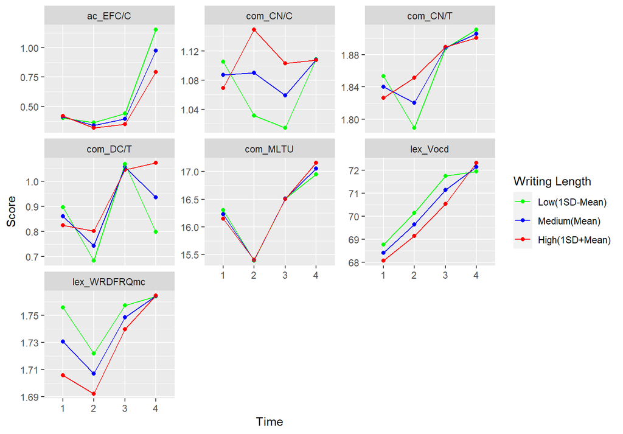